# Chapter 3 Homework

7/9/2020

### Question 1

Consider a game in which two players, Fred and Barney, take turns removing matchsticks from a pile. They start with 21 matchsticks, and Fred goes first. On each turn, each player may remove either one, two, three, or four matchsticks. The player to remove the last matchstick wins the game.

1. Suppose there are only six matchsticks left, and it is Barney’s turn. What move should Barney make to guarantee himself victory? Explain your reasoning.
2. Suppose there are 12 matchsticks left, and it is Barney’s turn. What move should Barney make to guarantee himself victory?
3. Now start from the beginning of the game. If both players play optimally, who will win?
4. What are the optimal strategies for each player?

### Question 2

Consider the game in the previous exercise. Suppose the players have reached a point where it is Fred’s move and there are just five matchsticks left.

1. Draw the game tree for the game this game starting with five matchsticks.
2. Find the rollback equilibria for this game starting with five matchsticks.
3. Would you say this five-matchstick game has a first-mover or second-mover advantage?
4. Explain how you found more than one rollback equilibrium. How is your answer related to the optimal strategies you found in part (c) of the previous exercise?

### Question 3

In each of the following games, how many pure strategies are available to each player? List all of the pure strategies for each player.

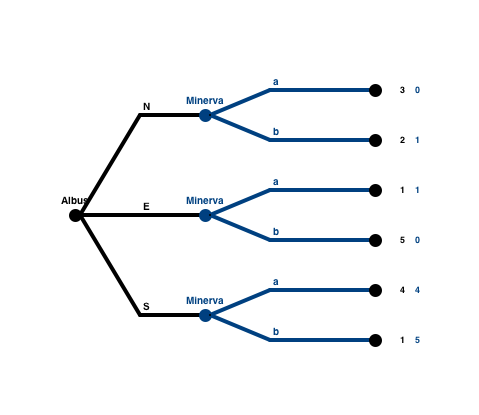

1. Game A

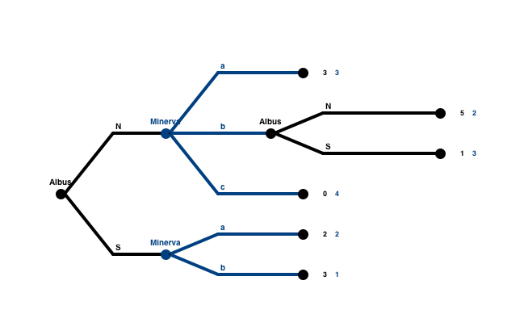

2. Game B

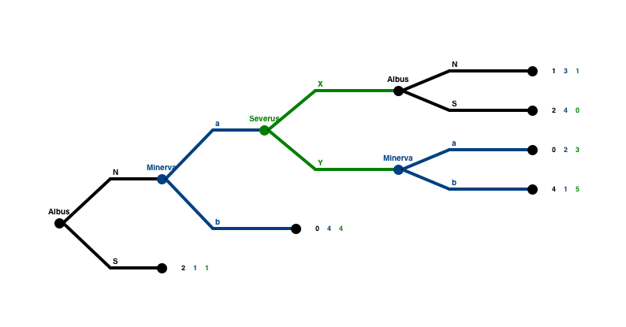

3. Game C

### Question 4

For each of the games illustrated in question 3, identify the rollback equilibrium outcome and the complete equilibrium strategy for each player.

### Question 5

Two distinct proposals, A and B, are being debated in Washington. Congress likes proposal A, and the president likes proposal B. The proposals are not mutually exclusive; either or both or neither may become law. Thus there are four possible outcomes, and the rankings of the two sides are as follows, where a larger number represents a more favored outcome:

| **Outcome** | **Congress** | **President** |
| --- | --- | --- |
| A becomes law | 4 | 1 |
| B becomes law | 1 | 4 |
| Both A and B become law | 3 | 3 |
| Neither (status quo prevails) | 2 | 2 |

1. The moves in the game are as follows. First, Congress decides whether to pass a bill and whether the bill is to contain A or B or both. Then the president decides to sign or veto the bill. Congress does not have enough votes to override a veto. Draw a tree for this game and find the rollback equilibrium.